# Case Study: Income Prediction

# Methodology: CRISP-DM Cross Industry Standard Process for Data mining

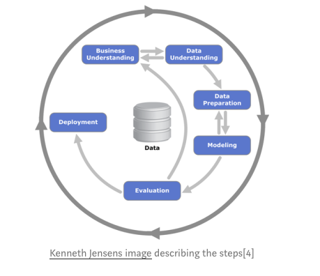

Crisp DM

## Business Understanding

Marketing department at a financial planning company would like to identify prospective customers from a database that it purchases. The target customer is anyone with an annual income over $50,000, but we do not get income information about our new customers. Therefore, we’d like to develop a model that analyzes other factors to help us predict whether a potential custom has an income over the $50,000 threshold. We’ll use logistic regression for this task

## Data Understanding

```r
glimpse(income)
```

```
Rows: 32,560
Columns: 12
$ age                <dbl> 50, 38, 53, 28, 37, 49, 52, 31, 42, 37, 30, 23, 32, 40, 34, 25, 32, 38, 43, 40, 54, 35, 43, 59, 56, 19, 54,…
$ workClassification <fct> Self-emp-not-inc, Private, Private, Private, Private, Private, Self-emp-not-inc, Private, Private, Private,…
$ educationLevel     <fct> Bachelors, HS-grad, 11th, Bachelors, Masters, 9th, HS-grad, Masters, Bachelors, Some-college, Bachelors, Ba…
$ educationYears     <dbl> 13, 9, 7, 13, 14, 5, 9, 14, 13, 10, 13, 13, 12, 11, 4, 9, 9, 7, 14, 16, 9, 5, 7, 9, 13, 9, 10, 9, 9, 12, 10…
$ maritalStatus      <fct> Married-civ-spouse, Divorced, Married-civ-spouse, Married-civ-spouse, Married-civ-spouse, Married-spouse-ab…
$ occupation         <fct> Exec-managerial, Handlers-cleaners, Handlers-cleaners, Prof-specialty, Exec-managerial, Other-service, Exec…
$ relationship       <fct> Husband, Not-in-family, Husband, Wife, Wife, Not-in-family, Husband, Not-in-family, Husband, Husband, Husba…
$ race               <fct> White, White, Black, Black, White, Black, White, White, White, Black, Asian-Pac-Islander, White, Black, Asi…
$ gender             <fct> Male, Male, Male, Female, Female, Female, Male, Female, Male, Male, Male, Female, Male, Male, Male, Male, M…
$ workHours          <dbl> 13, 40, 40, 40, 40, 16, 45, 50, 40, 80, 40, 30, 50, 40, 45, 35, 40, 50, 45, 60, 20, 40, 40, 40, 40, 40, 60,…
$ nativeCountry      <fct> United-States, United-States, United-States, Cuba, United-States, Jamaica, United-States, United-States, Un…
$ income             <fct> <=50K, <=50K, <=50K, <=50K, <=50K, <=50K, >50K, >50K, >50K, >50K, >50K, <=50K, <=50K, >50K, <=50K, <=50K, <…
```

### Data Exploration

```r
income %>%
  keep(is.factor) %>%
  summary()
```

```
        workClassification      educationLevel                maritalStatus             occupation           relationship
 Private         :22696    HS-grad     :10501   Married-civ-spouse   :14976   Prof-specialty :4140   Husband       :13193
 Self-emp-not-inc: 2541    Some-college: 7291   Divorced             : 4443   Craft-repair   :4099   Not-in-family : 8304
 Local-gov       : 2093    Bachelors   : 5354   Married-spouse-absent:  418   Exec-managerial:4066   Wife          : 1568
 ?               : 1836    Masters     : 1723   Never-married        :10682   Adm-clerical   :3769   Own-child     : 5068
 State-gov       : 1297    Assoc-voc   : 1382   Separated            : 1025   Sales          :3650   Unmarried     : 3446
 Self-emp-inc    : 1116    11th        : 1175   Married-AF-spouse    :   23   Other-service  :3295   Other-relative:  981
 (Other)         :  981    (Other)     : 5134   Widowed              :  993   (Other)        :9541
                 race          gender            nativeCountry     income
 White             :27815   Male  :21789   United-States:29169   <=50K:24719
 Black             : 3124   Female:10771   Mexico       :  643   >50K : 7841
 Asian-Pac-Islander: 1039                  ?            :  583
 Amer-Indian-Eskimo:  311                  Philippines  :  198
 Other             :  271                  Germany      :  137
                                           Canada       :  121
                                           (Other)      : 1709
```

Value Distribution of variable: workClassification

```r
income %>%
  select(workClassification) %>%
  table()
```

```
.
Self-emp-not-inc          Private        State-gov      Federal-gov        Local-gov                ?     Self-emp-inc      Without-pay
            2541            22696             1297              960             2093             1836             1116               14
    Never-worked
               7
```

Value Distribution of variable: educationLevel

```r
income %>%
  select(educationLevel) %>%
  table()
```

```
.
   Bachelors      HS-grad         11th      Masters          9th Some-college   Assoc-acdm    Assoc-voc      7th-8th    Doctorate
        5354        10501         1175         1723          514         7291         1067         1382          646          413
 Prof-school      5th-6th         10th      1st-4th    Preschool         12th
         576          333          933          168           51          433
```

Value Distribution of variable: occupation

```r
income %>%
  select(occupation) %>%
  table()
```

```
.
  Exec-managerial Handlers-cleaners    Prof-specialty     Other-service      Adm-clerical             Sales      Craft-repair
             4066              1370              4140              3295              3769              3650              4099
 Transport-moving   Farming-fishing Machine-op-inspct      Tech-support                 ?   Protective-serv      Armed-Forces
             1597               994              2002               928              1843               649                 9
  Priv-house-serv
              149
```

Value Distribution of variable: nativeCountry

```r
income %>%
  select(nativeCountry) %>%
  table()
```

```
.
             United-States                       Cuba                    Jamaica                      India                          ?
                     29169                         95                         81                        100                        583
                    Mexico                      South                Puerto-Rico                   Honduras                    England
                       643                         80                        114                         13                         90
                    Canada                    Germany                       Iran                Philippines                      Italy
                       121                        137                         43                        198                         73
                    Poland                   Columbia                   Cambodia                   Thailand                    Ecuador
                        60                         59                         19                         18                         28
                      Laos                     Taiwan                      Haiti                   Portugal         Dominican-Republic
                        18                         51                         44                         37                         70
               El-Salvador                     France                  Guatemala                      China                      Japan
                       106                         29                         64                         75                         62
                Yugoslavia                       Peru Outlying-US(Guam-USVI-etc)                   Scotland            Trinadad&Tobago
                        16                         31                         14                         12                         19
                    Greece                  Nicaragua                    Vietnam                       Hong                    Ireland
                        29                         34                         67                         20                         24
                   Hungary         Holand-Netherlands
                        13                          1
```

## Data Preparation

Replace unknown values for workClassification, occupation, and nativeCountry with code (UNK)

```r
income %>%
  select(workClassification,nativeCountry,occupation) %>%
  summary()
```

```
        workClassification       nativeCountry             occupation
 Private         :22696    United-States:29169   Prof-specialty :4140
 Self-emp-not-inc: 2541    Mexico       :  643   Craft-repair   :4099
 Local-gov       : 2093    UNK          :  583   Exec-managerial:4066
 UNK             : 1836    Philippines  :  198   Adm-clerical   :3769
 State-gov       : 1297    Germany      :  137   Sales          :3650
 Self-emp-inc    : 1116    Canada       :  121   Other-service  :3295
 (Other)         :  981    (Other)      : 1709   (Other)        :9541
```

Transform income variable to binary

```r
income %>%
  select(income) %>%
  summary()
```

```
 income
 0:24719
 1: 7841
```

Splitting Testing and Training Data Set

```r
income_train %>%
  nrow()
```

```
[1] 24420
```

Check Class Distribution

```r
colnames(income)
```

```
 [1] "age"                "workClassification" "educationLevel"     "educationYears"     "maritalStatus"      "occupation"
 [7] "relationship"       "race"               "gender"             "workHours"          "nativeCountry"      "income"
```

```r
income %>%
  select(income) %>%
  table() %>%
  prop.table() * 100
```

```
.
      0       1
75.9183 24.0817
```

```r
income_train %>%
  select(income) %>%
  table() %>%
  prop.table() * 100
```

```
.
      0       1
75.8231 24.1769
```

```r
income_test %>%
  select(income) %>%
  table() %>%
  prop.table() * 100
```

```
.
       0        1
76.20393 23.79607
```

Balance the training data set with SMOTE()

```r
income_train %>%
  select(income) %>%
  table() %>%
  prop.table() * 100
```

```
.
 0  1
50 50
```

## Modeling

Training The Model

```r
summary(income_mod1)
```

```
Call:
glm(formula = income ~ ., family = binomial, data = .)

Deviance Residuals:
    Min       1Q   Median       3Q      Max
-3.6941  -0.6542   0.0121   0.6897   3.3364

Coefficients:
                                         Estimate Std. Error z value Pr(>|z|)
(Intercept)                               1.88070    0.07797  24.121  < 2e-16 ***
workClassificationPrivate                -0.06591    0.05961  -1.106 0.268865
workClassificationState-gov              -0.20513    0.10135  -2.024 0.042978 *
workClassificationFederal-gov             1.01707    0.10062  10.108  < 2e-16 ***
workClassificationLocal-gov               0.21613    0.08324   2.596 0.009418 **
workClassificationUNK                    -0.32512    0.20116  -1.616 0.106054
workClassificationSelf-emp-inc            0.72351    0.10444   6.927 4.29e-12 ***
workClassificationWithout-pay           -13.40704  263.47540  -0.051 0.959417
workClassificationNever-worked          -10.17924  594.36174  -0.017 0.986336
educationLevelHS-grad                    -1.14177    0.05313 -21.490  < 2e-16 ***
educationLevel11th                       -1.64061    0.12815 -12.802  < 2e-16 ***
educationLevelMasters                     0.38736    0.07647   5.065 4.08e-07 ***
educationLevel9th                        -2.49985    0.22510 -11.106  < 2e-16 ***
educationLevelSome-college               -0.88793    0.05570 -15.942  < 2e-16 ***
educationLevelAssoc-acdm                 -0.51380    0.09202  -5.583 2.36e-08 ***
educationLevelAssoc-voc                  -0.69673    0.08518  -8.179 2.86e-16 ***
educationLevel7th-8th                    -2.40859    0.18880 -12.757  < 2e-16 ***
educationLevelDoctorate                   0.80775    0.16061   5.029 4.92e-07 ***
educationLevelProf-school                 1.46106    0.14196  10.292  < 2e-16 ***
educationLevel5th-6th                    -2.78638    0.31083  -8.964  < 2e-16 ***
educationLevel10th                       -2.03297    0.15088 -13.474  < 2e-16 ***
educationLevel1st-4th                    -4.24862    0.83223  -5.105 3.31e-07 ***
educationLevelPreschool                 -14.95090  163.66083  -0.091 0.927212
educationLevel12th                       -1.90844    0.21789  -8.759  < 2e-16 ***
maritalStatusDivorced                    -0.59974    0.06556  -9.148  < 2e-16 ***
maritalStatusMarried-spouse-absent       -0.53036    0.16115  -3.291 0.000998 ***
maritalStatusNever-married               -1.36186    0.06556 -20.771  < 2e-16 ***
maritalStatusSeparated                   -1.15784    0.12576  -9.206  < 2e-16 ***
maritalStatusMarried-AF-spouse            0.15729    0.50436   0.312 0.755151
maritalStatusWidowed                     -0.56799    0.11477  -4.949 7.46e-07 ***
occupationHandlers-cleaners              -1.63599    0.13106 -12.482  < 2e-16 ***
```

[output cut: 59 more lines]

```
nativeCountryVietnam                     -0.93045    0.49100  -1.895 0.058091 .
nativeCountryHong                        -0.07571    0.58595  -0.129 0.897191
nativeCountryIreland                      0.83491    0.52263   1.598 0.110152
nativeCountryHungary                      0.08809    0.60050   0.147 0.883371
nativeCountryHoland-Netherlands         -11.18565  882.74339  -0.013 0.989890
---
Signif. codes:  0 ‘***’ 0.001 ‘**’ 0.01 ‘*’ 0.05 ‘.’ 0.1 ‘ ’ 1

(Dispersion parameter for binomial family taken to be 1)

    Null deviance: 32739  on 23615  degrees of freedom
Residual deviance: 20322  on 23521  degrees of freedom
AIC: 20512

Number of Fisher Scoring iterations: 13
```

## Evaluation

Generating predictions against data - probabilities from 0 - 1

```r
head(income_pred1)
```

```
        1         2         3         4         5         6
0.2537639 0.9234300 0.4391130 0.7467588 0.1209514 0.8530749
```

Determine the ideal cutt-off point with function: ideal_cuttoff

```r
ideal_cutoff
```

```
[1] 0.4194126
```

Recode predictions using the ideal cutt-off

```r
head(income_pred1)
```

```
1 2 3 4 5 6
0 1 1 1 0 1
```

Evaluate model against test data

```r
sum(diag(income_pred1.table)) / nrow(income_test)
```

```
[1] 0.7476658
```